# clustering

```python
import pandas as pd
import numpy as np

df = pd.read_excel("/Users/jack/Desktop/OnlineRetail.xlsx")

df.head()
df.info()
```

```
<class 'pandas.core.frame.DataFrame'>
RangeIndex: 541909 entries, 0 to 541908
Data columns (total 8 columns):
 #   Column       Non-Null Count   Dtype
---  ------       --------------   -----
 0   InvoiceNo    541909 non-null  object
 1   StockCode    541909 non-null  object
 2   Description  540455 non-null  object
 3   Quantity     541909 non-null  int64
 4   InvoiceDate  541909 non-null  datetime64[ns]
 5   UnitPrice    541909 non-null  float64
 6   CustomerID   406829 non-null  float64
 7   Country      541909 non-null  object
dtypes: datetime64[ns](1), float64(2), int64(1), object(4)
memory usage: 33.1+ MB
```

### Removing Returns (`InvoiceNo` starts with `'C'`)

In this dataset, rows with `InvoiceNo` starting with `'C'` indicate **cancellations or returns**, according to the [UCI Online Retail dataset documentation](https://archive.ics.uci.edu/ml/datasets/online+retail).

These entries often include:

- Negative `Quantity`

Such records reflect reversed transactions and can **distort behavior-based features** like frequency, monetary value, and impulse patterns.

To ensure clean, intent-driven purchase data, we exclude them from analysis:

```python
df[df['InvoiceNo'].astype(str).str.startswith('C')].head()
```

|  | InvoiceNo | StockCode | Description | Quantity | InvoiceDate | UnitPrice | CustomerID | Country |
| --- | --- | --- | --- | --- | --- | --- | --- | --- |
| 141 | C536379 | D | Discount | -1 | 2010-12-01 09:41:00 | 27.50 | 14527.0 | United Kingdom |
| 154 | C536383 | 35004C | SET OF 3 COLOURED FLYING DUCKS | -1 | 2010-12-01 09:49:00 | 4.65 | 15311.0 | United Kingdom |
| 235 | C536391 | 22556 | PLASTERS IN TIN CIRCUS PARADE | -12 | 2010-12-01 10:24:00 | 1.65 | 17548.0 | United Kingdom |
| 236 | C536391 | 21984 | PACK OF 12 PINK PAISLEY TISSUES | -24 | 2010-12-01 10:24:00 | 0.29 | 17548.0 | United Kingdom |
| 237 | C536391 | 21983 | PACK OF 12 BLUE PAISLEY TISSUES | -24 | 2010-12-01 10:24:00 | 0.29 | 17548.0 | United Kingdom |

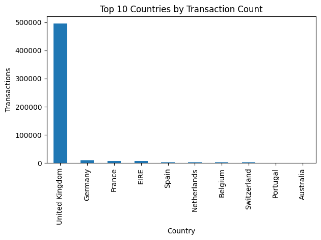

```python
import matplotlib.pyplot as plt

df['Country'].value_counts().head(10).plot(kind='bar', title='Top 10 Countries by Transaction Count')
plt.xlabel("Country")
plt.ylabel("Transactions")
plt.tight_layout()
plt.show()
```

**Observation**:  
The vast majority of transactions come from the **United Kingdom**, while other countries contribute negligible amounts.

**Insight**:  
To avoid bias in clustering due to unbalanced regional distribution, it's safer to **analyze only the UK market**.

```python
df = df[df['Country'] == 'United Kingdom']
```

```python
df.describe()
```

|  | Quantity | InvoiceDate | UnitPrice | CustomerID |
| --- | --- | --- | --- | --- |
| count | 495478.000000 | 495478 | 495478.000000 | 361878.000000 |
| mean | 8.605486 | 2011-07-04 05:01:41.098131456 | 4.532422 | 15547.871368 |
| min | -80995.000000 | 2010-12-01 08:26:00 | -11062.060000 | 12346.000000 |
| 25% | 1.000000 | 2011-03-27 12:06:00 | 1.250000 | 14194.000000 |
| 50% | 3.000000 | 2011-07-19 11:47:00 | 2.100000 | 15514.000000 |
| 75% | 10.000000 | 2011-10-20 10:41:00 | 4.130000 | 16931.000000 |
| max | 80995.000000 | 2011-12-09 12:49:00 | 38970.000000 | 18287.000000 |
| std | 227.588756 | NaN | 99.315438 | 1594.402590 |

**Action**:

- Remove negative values
- Apply upper quantile filtering to reduce extreme outliers

```python
df = df[df['Quantity'] > 0]
q_upper = df['Quantity'].quantile(0.99)
df = df[df['Quantity'] <= q_upper]
```

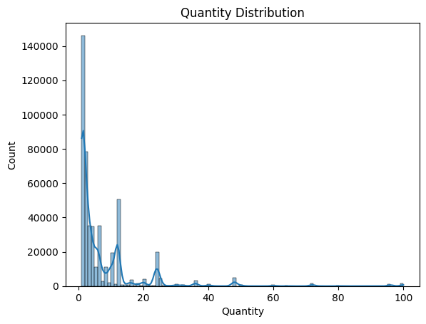

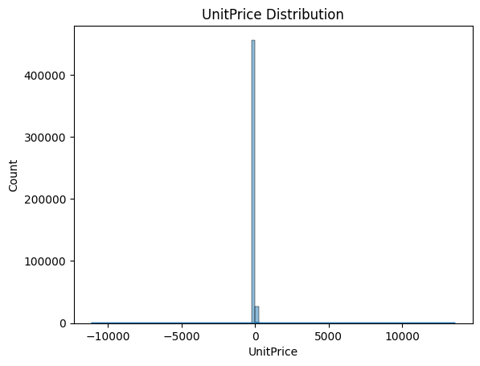

```python
import seaborn as sns

sns.histplot(df['Quantity'], bins=100, kde=True)
plt.title('Quantity Distribution')
plt.show()

sns.histplot(df['UnitPrice'], bins=100, kde=True)
plt.title('UnitPrice Distribution')
plt.show()
```

**Action**:

- Remove prices ≤ 0
- Cut the upper 0.5% to remove outliers

```python
df = df[df['UnitPrice'] > 0]
up_upper = df['UnitPrice'].quantile(0.995)
df = df[df['UnitPrice'] <= up_upper]
```

```python
df.describe()
```

|  | Quantity | InvoiceDate | UnitPrice | CustomerID |
| --- | --- | --- | --- | --- |
| count | 479847.000000 | 479847 | 479847.000000 | 350497.000000 |
| mean | 7.361136 | 2011-07-04 16:19:59.352793600 | 3.209491 | 15550.036779 |
| min | 1.000000 | 2010-12-01 08:26:00 | 0.001000 | 12747.000000 |
| 25% | 1.000000 | 2011-03-27 14:28:00 | 1.250000 | 14194.000000 |
| 50% | 3.000000 | 2011-07-20 11:22:00 | 2.100000 | 15518.000000 |
| 75% | 10.000000 | 2011-10-20 14:13:00 | 4.130000 | 16931.000000 |
| max | 100.000000 | 2011-12-09 12:49:00 | 24.960000 | 18287.000000 |
| std | 11.848124 | NaN | 3.202143 | 1593.100141 |

```python
df['TotalPrice'] = df['Quantity'] * df['UnitPrice']
```

This column is essential for RFM calculations and understanding revenue per transaction.

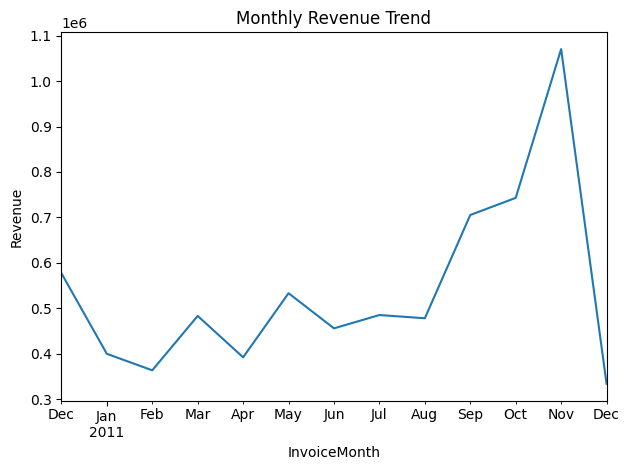

```python
df['InvoiceMonth'] = df['InvoiceDate'].dt.to_period('M')
monthly_sales = df.groupby('InvoiceMonth')['TotalPrice'].sum()

monthly_sales.plot(title='Monthly Revenue Trend')
plt.ylabel('Revenue')
plt.tight_layout()
plt.show()
```

Before clustering, it's important to analyze **temporal trends** in revenue to identify potential seasonal effects or data collection bias.

We grouped transactions by month and plotted total revenue to observe trends over time:

```
df['InvoiceMonth'] = df['InvoiceDate'].dt.to_period('M')
```

Observations

- **November** shows a **sharp revenue spike**, likely due to seasonal events such as **Black Friday promotions** or **holiday shopping**.
- **December** shows a **sudden drop**, which aligns with the fact that the dataset ends on **December 9, 2011** — not a full month.
- **Mid-year months** (June–August) show relatively **flat performance**, possibly reflecting **seasonal consumer behavior**.

Insights

This time-based trend **significantly affects features like `Recency` and `Monetary`**, particularly for customers active during the **holiday season (November–December)**.

To account for this seasonality, we apply **feature normalization** prior to clustering, ensuring that temporary spikes or cut-off effects from incomplete months do not distort the segmentation outcomes.

```python
reference_date = df['InvoiceDate'].max() + pd.Timedelta(days=1)
recency = df.groupby('CustomerID')['InvoiceDate'].max().apply(lambda x: (reference_date - x).days)

frequency = df.groupby('CustomerID')['InvoiceNo'].nunique()

monetary = df.groupby('CustomerID')['TotalPrice'].sum()
```

```python
df = df.sort_values(['CustomerID', 'InvoiceDate'])
df['TimeDiff'] = df.groupby('CustomerID')['InvoiceDate'].diff().dt.days

ipt = df.groupby('CustomerID')['TimeDiff'].mean().fillna(0)

impulse_count = df[df['TimeDiff'] <= 2].groupby('CustomerID')['TimeDiff'].count()
total_count = df.groupby('CustomerID')['TimeDiff'].count()
impulse_score = (impulse_count / total_count).fillna(0)
```

### Features for Clustering

- **`Recency`** - Days since last purchase → captures customer freshness
- **`Frequency`** – Total transactions → reflects engagement & loyalty
- **`Monetary`** – Total spending → measures customer value
- **`InterpurchaseTime`** – Avg. days between purchases → buying rhythm
- **`ImpulseScore`** – % of purchases ≤ 2 days apart → impulsiveness indicator

> Together, these features form a behavior-rich profile of each customer, enabling more nuanced segmentation than RFM alone.

```python
rfm = pd.DataFrame({
    'Recency': recency,
    'Frequency': frequency,
    'Monetary': monetary,
    'InterpurchaseTime': ipt,
    'ImpulseScore': impulse_score
})

features = ['Recency', 'Frequency', 'Monetary', 'InterpurchaseTime', 'ImpulseScore']
```

```python
rfm[features].describe()
```

|  | Recency | Frequency | Monetary | InterpurchaseTime | ImpulseScore |
| --- | --- | --- | --- | --- | --- |
| count | 3878.000000 | 3878.000000 | 3878.000000 | 3878.000000 | 3878.000000 |
| mean | 92.366942 | 4.176122 | 1467.214875 | 3.016179 | 0.942194 |
| std | 99.679498 | 6.976372 | 3371.505520 | 8.835415 | 0.150619 |
| min | 1.000000 | 1.000000 | 2.900000 | 0.000000 | 0.000000 |
| 25% | 18.000000 | 1.000000 | 281.470000 | 0.000000 | 0.950000 |
| 50% | 51.000000 | 2.000000 | 618.790000 | 1.061335 | 0.978022 |
| 75% | 144.000000 | 5.000000 | 1489.292500 | 2.961806 | 1.000000 |
| max | 374.000000 | 205.000000 | 71615.640000 | 309.000000 | 1.000000 |

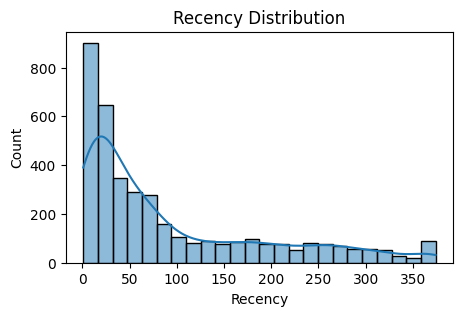

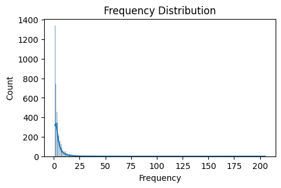

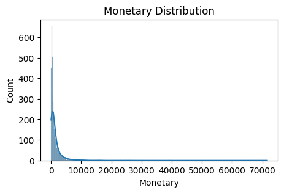

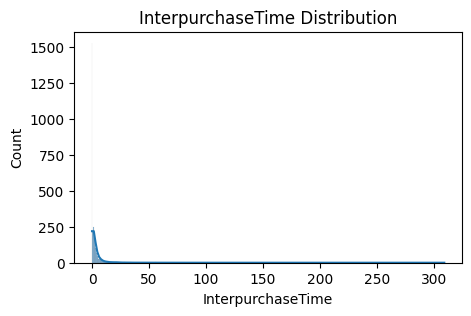

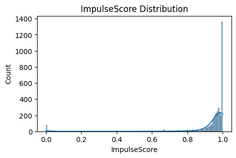

```python
for feature in features:
    plt.figure(figsize=(5, 3))
    sns.histplot(rfm[feature], kde=True)
    plt.title(f'{feature} Distribution')
    plt.show()
```

Frequency, Monetary, InterpurchaseTime

These features contain extreme outliers.  
A few customers purchased hundreds of times or spent tens of thousands, while most others remained in a much lower range.

Standardization alone cannot resolve this imbalance—  
the presence of large values inflates the mean and standard deviation, weakening comparisons between typical customers.

To address this, a log transformation (`log1p`) is applied first.  
This reduces the impact of large values and compresses the scale, creating a more balanced input for clustering.

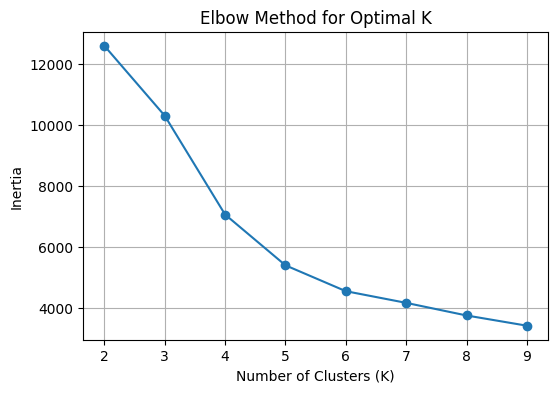

```python
from sklearn.preprocessing import StandardScaler
from sklearn.cluster import KMeans
import matplotlib.pyplot as plt
from sklearn.metrics import silhouette_score

log_cols = ['Frequency', 'Monetary', 'InterpurchaseTime']
for col in log_cols:
    rfm[col] = np.log1p(rfm[col])

scaler = StandardScaler()
X_scaled = scaler.fit_transform(rfm[features])

inertia = []
K_range = range(2, 10)

for k in K_range:
    kmeans = KMeans(n_clusters=k, random_state=42, n_init='auto')
    kmeans.fit(X_scaled)
    inertia.append(kmeans.inertia_)

plt.figure(figsize=(6, 4))
plt.plot(K_range, inertia, marker='o')
plt.title('Elbow Method for Optimal K')
plt.xlabel('Number of Clusters (K)')
plt.ylabel('Inertia')
plt.grid(True)
plt.show()
```

```python
print("silhouette Scores:")
for k in K_range:
    kmeans = KMeans(n_clusters=k, random_state=42, n_init='auto')
    labels = kmeans.fit_predict(X_scaled)
    score = silhouette_score(X_scaled, labels)
    print(f"K={k}→ Silhouette Score: {score:.4f}")
```

```
silhouette Scores:
K=2→ Silhouette Score: 0.3773
K=3→ Silhouette Score: 0.3178
K=4→ Silhouette Score: 0.3501
K=5→ Silhouette Score: 0.3738
K=6→ Silhouette Score: 0.3542
K=7→ Silhouette Score: 0.3543
K=8→ Silhouette Score: 0.3663
K=9→ Silhouette Score: 0.3365
```

Based on the Elbow Method and Silhouette Scores, K=4 and K=5 were selected for comparison:

Both values are reasonable. Clustering will be performed for K=4 and K=5, followed by a behavioral interpretation of each segment.

```python
k4 = KMeans(n_clusters=4, random_state=42, n_init='auto')
rfm['Cluster_K4'] = k4.fit_predict(X_scaled)

k4_summary = rfm.groupby('Cluster_K4')[features].mean().round(2)
k4_summary
```

| Cluster_K4 | Recency | Frequency | Monetary | InterpurchaseTime | ImpulseScore |
| --- | --- | --- | --- | --- | --- |
| 0 | 155.73 | 0.77 | 5.59 | 0.07 | 1.00 |
| 1 | 61.07 | 1.38 | 6.51 | 1.66 | 0.93 |
| 2 | 25.96 | 2.27 | 8.04 | 0.91 | 0.95 |
| 3 | 183.50 | 0.89 | 4.64 | 0.96 | 0.02 |

```python
k5 = KMeans(n_clusters=5, random_state=42, n_init='auto')
rfm['Cluster_K5'] = k5.fit_predict(X_scaled)

k5_summary = rfm.groupby('Cluster_K5')[features].mean().round(2)
k5_summary
```

| Cluster_K5 | Recency | Frequency | Monetary | InterpurchaseTime | ImpulseScore |
| --- | --- | --- | --- | --- | --- |
| 0 | 57.19 | 0.82 | 5.77 | 0.10 | 0.99 |
| 1 | 61.89 | 1.39 | 6.50 | 1.80 | 0.93 |
| 2 | 26.93 | 2.26 | 8.02 | 0.92 | 0.95 |
| 3 | 183.50 | 0.89 | 4.64 | 0.96 | 0.02 |
| 4 | 263.53 | 0.80 | 5.54 | 0.16 | 0.99 |

### Feature Definitions

| Feature | Meaning | High Value | Low Value |
| --- | --- | --- | --- |
| **Recency** | Days since last purchase | Inactive / lapsed | Recently active |
| **Frequency** | Number of purchase events | Loyal / frequent buyer | One-time / irregular |
| **Monetary** | Total amount spent | High-value customer | Low spender |
| **InterpurchaseTime** | Avg. days between purchases | Irregular / slow cycle | Consistent / clustered buying |
| **ImpulseScore** | % of purchases within 2 days of the last one | Impulsive / reactive behavior | Deliberate / planned behavior |

While K=4 provides a solid segmentation structure, K=5 introduces a valuable refinement:

- In K=4, Cluster 0 grouped all low-frequency impulsive buyers together.
- In K=5, that group is **further split into two distinct profiles**:
  - One with moderate recency (Cluster 0)
  - One with very high recency (Cluster 4)

This distinction allows us to **separate active impulse buyers from lapsed one-time responders**

### K=5 Cluster Summary

| Cluster | Profile | Key Traits | Strategy |
| --- | --- | --- | --- |
| 0 | Active Impulse Buyers | Recent purchase, low frequency, high impulse | Flash deals, urgency campaigns |
| 1 | Occasional Impulse Buyers | Moderate recency, occasional purchases, impulsive | Retargeting, interest-based push |
| 2 | Loyal High-Value Customers | Frequent, recent, high spending, impulsive | Loyalty perks, early access |
| 3 | Inactive Planned Buyers | Very old recency, low impulse | Low priority, minimal targeting |
| 4 | Dormant Impulse Responders | Long inactive, low frequency, high impulse | Reactivation, FOMO-based offers |

### Transition to Emotion-Driven Enhancement

Behavioral clusters show what users do.  
To go further, we need to understand how they might feel.

Next, we simulate customer feedback and apply sentiment analysis.  
This links each cluster to emotional tone—adding depth for better messaging and UX decisions.

```python
from vaderSentiment.vaderSentiment import SentimentIntensityAnalyzer
import pandas as pd

synthetic_reviews = {
    0: "I usually shop when there’s a big sale, and I buy quickly without thinking much.",
    1: "I browse sometimes and buy if I find something interesting.",
    2: "I always come back. I love new arrivals and enjoy spending here.",
    3: "I shopped once, it was okay, but I don’t feel the need to return.",
    4: "It's been a while. I bought on impulse before, but haven’t looked again."
}

analyzer = SentimentIntensityAnalyzer()
sentiment_results = {
    cluster: analyzer.polarity_scores(text) for cluster, text in synthetic_reviews.items()
}

emotion_df = pd.DataFrame(sentiment_results).T
emotion_df.index.name = 'Cluster'
emotion_df = emotion_df[['pos', 'neu', 'neg', 'compound']]
emotion_df.round(2)
```

| Cluster | pos | neu | neg | compound |
| --- | --- | --- | --- | --- |
| 0 | 0.00 | 1.00 | 0.0 | 0.00 |
| 1 | 0.23 | 0.77 | 0.0 | 0.40 |
| 2 | 0.42 | 0.57 | 0.0 | 0.81 |
| 3 | 0.10 | 0.90 | 0.0 | 0.12 |
| 4 | 0.00 | 1.00 | 0.0 | 0.00 |

### Cluster-Level Emotion Summary

Sentiment analysis was run on simulated feedback per cluster.  
The `compound` score (-1 to +1) shows overall emotional tone.  
Higher scores = stronger engagement.  
Scores near 0 = neutral or indifferent attitudes.

| Cluster | Compound | Interpretation |
| --- | --- | --- |
| **0** | 0.00 | Purely neutral. Behavior is likely driven by short-term incentives, not emotional attachment. |
| **1** | 0.40 | Moderately positive tone. Occasional buyers may develop brand preference with continued engagement. |
| **2** | 0.81 | Strongly positive. Loyal and satisfied segment—core advocacy potential. |
| **3** | 0.12 | Mildly positive but mostly neutral. Past experience was fine, but emotional connection is weak. |
| **4** | 0.00 | Fully neutral. Past impulsive behavior did not translate into sentiment—suggests low emotional memory. |

**Insight**:  
Emotion adds depth to behavioral segmentation.  
Clusters 2 and 1 show emotional alignment with positive actions.  
Clusters 0 and 4 respond to stimuli but show no lasting brand affinity—ideal for tactical campaigns, not relationship building.

### UX Strategy by Cluster

| Cluster | User Mindset | UX Intervention |
| --- | --- | --- |
| 0 | “I buy when it’s fast, easy, and urgent” | One-click purchase, countdown timers |
| 1 | “I’m curious, but not committed yet” | Recently viewed lists, smart nudges |
| 2 | “This brand fits me. I come back often” | Personalized dashboards, loyalty progress |
| 3 | “I bought once. Didn’t hate it. Forgot.” | Gentle reactivation emails, "what’s new" |
| 4 | “I bought once on a whim, now I’m gone” | FOMO banners, comeback discounts, scarcity |

### Summary

This project delivers a complete customer segmentation system:

- **Behavioral clustering** defines key user groups
- **Sentiment analysis** adds emotional insight
- **UX strategies** personalize experience by segment

### ML Implementation:

To move from insight to application,  
a classification model was trained to map behavioral inputs to cluster labels.

```python
from sklearn.model_selection import train_test_split
from sklearn.ensemble import RandomForestClassifier
from sklearn.metrics import classification_report, confusion_matrix

X = rfm[['Recency', 'Frequency', 'Monetary', 'InterpurchaseTime', 'ImpulseScore']]
y = rfm['Cluster_K5']

X_train, X_test, y_train, y_test = train_test_split(X, y, test_size=0.2, random_state=42)

model = RandomForestClassifier(n_estimators=100, random_state=42)
model.fit(X_train, y_train)

y_pred = model.predict(X_test)

print(classification_report(y_test, y_pred))
print(confusion_matrix(y_test, y_pred))
```

```
              precision    recall  f1-score   support

           0       0.99      0.98      0.99       167
           1       0.97      0.96      0.97       237
           2       0.97      1.00      0.99       200
           3       1.00      1.00      1.00        14
           4       0.99      0.98      0.98       158

    accuracy                           0.98       776
   macro avg       0.99      0.99      0.99       776
weighted avg       0.98      0.98      0.98       776

[[164   3   0   0   0]
 [  1 228   6   0   2]
 [  0   0 200   0   0]
 [  0   0   0  14   0]
 [  0   3   0   0 155]]
```

```python
new_customer = pd.DataFrame({
    'Recency': [30],
    'Frequency': [1],
    'Monetary': [6.0],
    'InterpurchaseTime': [1.2],
    'ImpulseScore': [0.8]
})

predicted_cluster = model.predict(new_customer)
print(f"Predicted Cluster: {predicted_cluster[0]}")
```

```
Predicted Cluster: 1
```

```python
import pickle

with open('cluster_classifier.pkl', 'wb') as f:
    pickle.dump(model, f)

with open('scaler.pkl', 'wb') as f:
    pickle.dump(scaler, f)

rfm.to_csv('rfm_data.csv', index=False)
```